# Mini Project May 2020: Modelling Salary Data

Franziska Günther

2020-05-14

Next to the dataset that contains salary and sociodemographic data (possession of university degree, gender, ethnicity) for 1024 participants across 50 years, following packages must be loaded to replicate results.

```r
load("salary.Rdata")

library(gridExtra)
library(tidyverse)
library(ppcor)
```

# 1 Exploring the data set

We first have a look at the sociodemographic characteristics of participants.

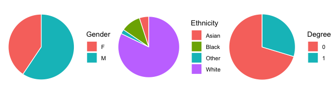

Further, we can have a look at the salary distribution of men and women across the observed time span.

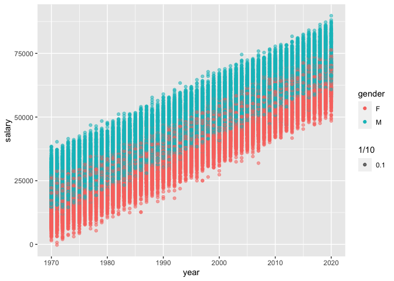

The following bar graph shows the absolute number of participants obtaining a university degree, and their ethnicity.

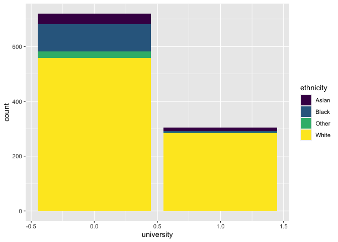

We can also plot salary development for participants belonging to a certain ethnicity.

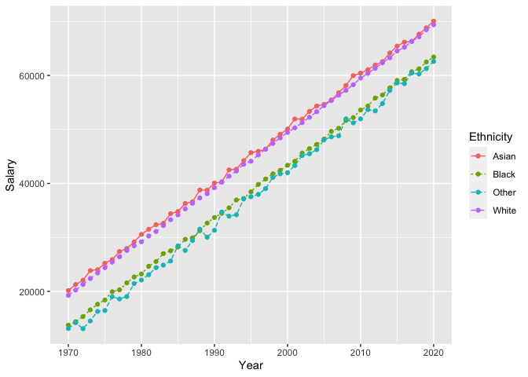

Since the possession of a university degree could in theory be subject to change over time, I investigated any change in this variable over time.

```r
n_person <- max(df$person)
graduation_list <- vector(mode = "list", length = n_person)

for (i in 1:n_person) {
  person_df = df[df$person == i, ]
  graduation_list[i] = unique(person_df$university)
}

print(length(graduation_list))
```

```
## [1] 1024
```

Since there is only one unique value on the variable University across years per participant (1024 values in total), I could be certain that the variable was conclusively set for each participant.

Alternatively, we could have verified this graphically by looking at the constant proportion of participants that held a university degree in each year.

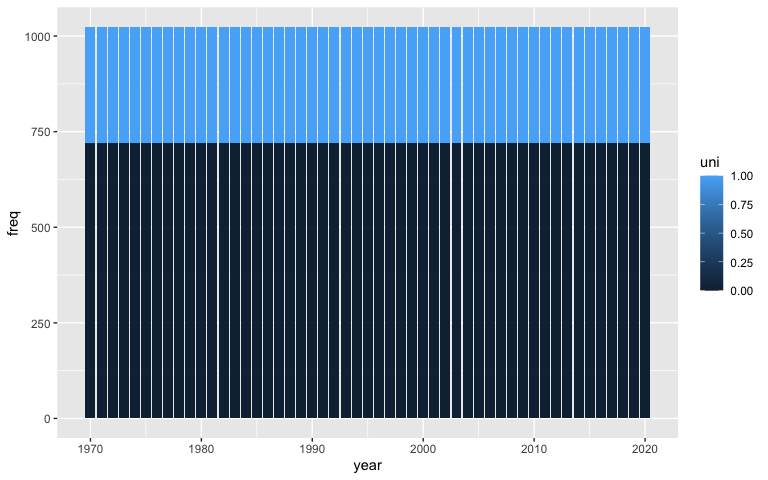

# 2 Modelling data

Since modelling raw data has been proven to result in poor model fit, we standardise both continuous variables Year and Salary.

```r
df$year_scaled <- (df$year - mean(df$year)) / (sd(df$year))
df$salary_scaled <- (df$salary - mean(df$salary)) / (sd(df$salary))
```

This resulted in a better model fit for a simple linear model regressing Salary on Year.

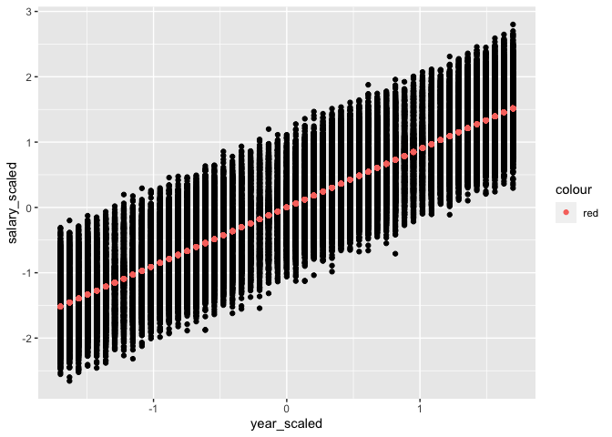

To study the effect of the available variables on wage growth, the following parameters of a more complex general linear model inclusive of all available covariates are estimated with maximum likelihood:

$$\theta = \{ \beta_{y_0}, \beta_{y_1}, \beta_{u_0}, \beta_{u_1}, \beta_{g_0}, \beta_{g_1}, \beta_{e_0}, \beta_{e_1}, \beta_{e_2}, \beta_{e_3}, \sigma^2 \}$$

The respective log likelihood function is derived as follows (University, Gender and Ethnicity are dummy-coded):

$$L(\theta) = p(s_1, .., s_n | y_1, .., y_n, u_1, .., u_n, g_1, .., g_n, e_1, .., e_n, \theta )$$
$$= \prod_{i=1}^{n} \frac{1}{\sqrt{2 \pi \sigma^2}} \exp\Big[-\frac{s_i - \beta_{y_0} - \beta_{y_1} y_i - \beta_{u_0} - \beta_{u_1} u_i - \beta_{g_0} - \beta_{g_1} g_i - \beta_{e_0} - \beta_{e_1} e_{i_1} - \beta_{e_2} e_{i_2} - \beta_{e_3} e_{i_3} }{ 2 \sigma^2}\Big]^2$$
$$= \frac{1}{(\sqrt{2 \pi \sigma^2})^{n/2}} \exp\Big[- \frac{1}{2 \sigma^2} \sum_{i=1}^{n} s_i - \beta_{y_0} - \beta_{y_1} y_i - \beta_{u_0} - \beta_{u_1} u_i - \beta_{g_0} - \beta_{g_1} g_i - \beta_{e_0} - \beta_{e_1} e_{i_1} - \beta_{e_2} e_{i_2} - \beta_{e_3} e_{i_3} \Big]^2$$
By modelling data in this way, we assume the following:

- the regression involves only linear and no polynomial functions of the covariates
- the effect of covariates on the response variable is purely additive
- the relationship between response and covariates is deterministic
- errors in the prediction of the response through linear combination of the covariates are additive and normally distributed with a mean of 0
- variance of errors is the same across all observations
- the distribution of the values on the response variable for every combination of covariate values is normal (implied by the likelihood function)
- covariates are neither subject to change nor noisy themselves
- it’s okay to treat salary information of one person across years like salary information of several people with the same characteristics

The code below performs the maximum likelihood estimation of the specified parameters:

```r
neglogLikelihood <- function(theta, obs) {

  beta_y0 = theta[1]
  beta_y1 = theta[2]
  beta_u0 = theta[3]
  beta_u1 = theta[4]
  beta_g0 = theta[5]
  beta_g1 = theta[6]
  beta_e0 = theta[7]
  beta_e1 = theta[8]
  beta_e2 = theta[9]
  beta_e3 = theta[10]
  sigma_squared = theta[11]

  n = obs[1]
  y = obs[1+c(1:n)]
  g = obs[1+c((n+1):(2*n))]
  e1 = obs[1+c(((2*n)+1):(3*n))]
  e2 = obs[1+c(((3*n)+1):(4*n))]
  e3 = obs[1+c(((4*n)+1):(5*n))]
  u = obs[1+c(((5*n)+1):(6*n))]
  s = obs[1+c(((6*n)+1):(7*n))]

  logF = dnorm(s, mean = (beta_y0 + beta_y1*y + beta_u0 + beta_u1*u + beta_g0 + beta_g1*g + beta_e0 + beta_e1*e1 + beta_e2*e2 + beta_e3*e3), sd = sigma_squared, log = TRUE)
  return(-sum(logF))
}

n <- length(df$person)

df$gender_dummy[df$gender == "M"] = 1
df$gender_dummy[df$gender == "F"] = 0

df$ethnicity_dummy1[df$ethnicity == "Black"] = 1
df$ethnicity_dummy1[df$ethnicity != "Black"] = 0

df$ethnicity_dummy2[df$ethnicity == "Other"] = 1
df$ethnicity_dummy2[df$ethnicity != "Other"] = 0

df$ethnicity_dummy3[df$ethnicity == "White"] = 1
df$ethnicity_dummy3[df$ethnicity != "White"] = 0

obs <- c(n, df$year_scaled, df$gender_dummy, df$ethnicity_dummy1, df$ethnicity_dummy2, df$ethnicity_dummy3, df$university, df$salary_scaled)
theta_init = c(1, 1, 1, 1, 1, 1, 1, 1, 1, 1, 1)

out <- optim(theta_init, neglogLikelihood, gr = NULL, obs, method = "L-BFGS-B", lower = c(-Inf, -Inf, -Inf, -Inf, -Inf, -Inf, -Inf, -Inf, -Inf, -Inf, 0.001), upper = c(Inf, Inf, Inf, Inf, Inf, Inf, Inf, Inf, Inf, Inf, Inf))

print(out$par)
```

```
##  [1] -0.09884148  0.89248550 -0.09884148  0.60590306 -0.09884148  0.60426064
##  [7] -0.09884148 -0.30808616 -0.43552768 -0.12269514  0.18216308
```

After fitting the model, we check if its predictions match the observed data by plotting observed against predicted Salary data. Apparently, the prediction is sufficiently good.

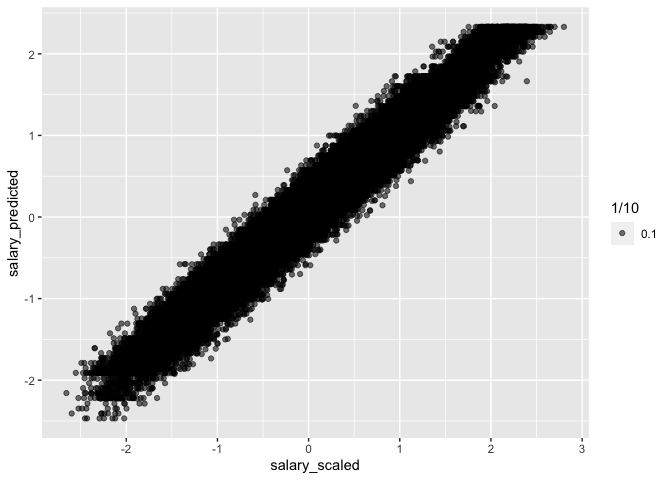

```r
df$salary_predicted <- beta_y0 + beta_y1*df$year_scaled + beta_u0 + beta_u1*df$university + beta_g0 + beta_g1*df$gender_dummy + beta_e0 + beta_e1*df$ethnicity_dummy1 + beta_e2*df$ethnicity_dummy2 + beta_e3*df$ethnicity_dummy2
plt = ggplot(df)
plt = plt + geom_point(mapping = aes(x = salary_scaled, y = salary_predicted, alpha = 1/10))
print(plt)
```

Further, we confirm that the distribution of the residual prediction errors matches our assumed noise model.

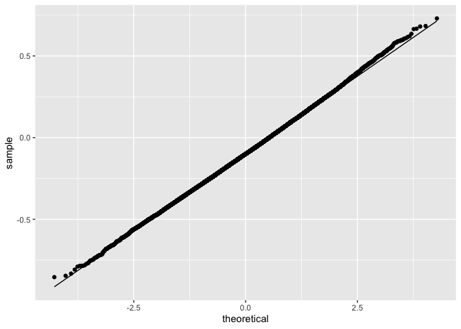

```r
df$residuals <- df$salary_scaled - df$salary_predicted
plt <- ggplot(df, aes(sample = residuals))
plt + stat_qq() + stat_qq_line()
```

# 3 Statistical inference

To determine which of the covariates is important for prediction of the response, I turned to testing their respective regression coefficients for significance within a permutation test.

The below function takes a specific variable (specified in “column” and “ethn_coef”), the desired number of permutations (“n_perm”) and the estimated coefficient (“beta_estimate”), and computes a p-value for it. It also outputs all coefficients computed within the permutation test. Covariates are fed into the linear model in the same order every time.

```r
permute_desired <- function(df, column, n_perm, ethn_coef=NULL, beta_estimate) {
  coefs = rep(0, n_perm)
  cols_tochoosefrom = c(7, 5, 3, 4) # indexes of columns storing covariates in
                                    # the original data frame

  for ( m in 1:n_perm ) {
    # storing permuted and unpermuted covariates side by side as columns
    # in a dataframe
    df_perm <- data.frame(year=integer(n),
                          university=integer(n),
                          gender=integer(n),
                          ethnicity=integer(n))

    # loops over covariates
    for ( i in 1:length(cols_tochoosefrom)) {

      # condition for selected covariate
      if (cols_tochoosefrom[i] == column) {

        # for covariate Year (column 7 in original dataframe), I decided
        # to shuffle years within a single participant
        if(column == 7) {

          yearcol = c()
          for (j in 1:n_person) {
            yearcol = append(yearcol, sample(df$year_scaled[df$person == j], 51, replace = FALSE))
          }

          # adds shuffled values to the column of the dataframe
          df_perm$year = yearcol

        } # for the other covariates, I shuffled values
          # across participants
        else {

          covariatecol = c()
          covariate_pperson <- rep(0, n_person)

          # find one value for each participant on the
          # respective covariate
          for (j in 1:n_person) {
            person_df = df[df$person == j, ]
            covariate_pperson[j] = unique(person_df[, column])
          }

          # shuffle those values
          covariate_pperson_shuffled = sample(covariate_pperson, n_person, replace=F)

          # populate the shuffled values
          for (k in 1:length(covariate_pperson_shuffled)) {
            covariatecol = append(covariatecol, rep(covariate_pperson_shuffled[k], 51))
          }

          # convert shuffled ethnicity column into a factor
          if(column == 4) {
            covariatecol[covariatecol == 1] = "Asian"
            covariatecol[covariatecol == 2] = "Black"
            covariatecol[covariatecol == 3] = "Other"
            covariatecol[covariatecol == 4] = "White"

            covariatecol = factor(covariatecol, levels = c("Asian", "Black" , "Other",   "White"))
          }

          df_perm[, i] = covariatecol
        }
      } else {

        # values are taken over unchanged for the other covariates
        unpermuted = cols_tochoosefrom[i]
        df_perm[, i] = df[, unpermuted]
      }
    }

    # At this point, it would also have been possible
    # to compute the squared semi-partial correlation
    # coefficient as a measure of relative importance
    # of the selected covariate to test for significance
    # of the correlation obtained from the original data.

    # The code chunk below shows how saving a correlation
    # value for a permuted Year column and an unpermuted
    # Salary column might look like. The respective
    # p-value would have been computed from the resulting
    # empirical distribution of correlations in a fashion
    # comparable to the computation below for regression
    # coefficients.

    # corr[m] <- (spcor(df_perm[,c(1, 5)])$estimate[1, 2])^2

    model <- lm(df$salary_scaled ~ df_perm$year + df_perm$university + df_perm$gender + df_perm$ethnicity)

    # coefficient for the selected covariate is inserted into
    # the vector of coefficients
    if(column == 7 & is.null(ethn_coef)) {
      coefs[m] = coef(model)["df_perm$year"]
    } else if (column == 5 & is.null(ethn_coef)) {
      coefs[m] = coef(model)["df_perm$university"]
    } else if (column == 3 & is.null(ethn_coef)) {
      coefs[m] = coef(model)["df_perm$gender"]
    } else if (column == 4 & ethn_coef == 1) {
      coefs[m] = coef(model)["df_perm$ethnicityBlack"]
    } else if (column == 4 & ethn_coef == 2) {
      coefs[m] = coef(model)["df_perm$ethnicityOther"]
    } else if (column == 4 & ethn_coef == 3) {
      coefs[m] = coef(model)["df_perm$ethnicityWhite"]
    }
  }

  permutation_p_value = sum( abs(coefs) > abs(beta_estimate) ) / n_perm

  return(c(permutation_p_value, coefs))

}
```

Below is what a function call looks like for the estimate of the regression coefficient of the variable Year.

```r
permute_desired(df, 7, 1000, beta_estimate=beta_y1)
```

The permutation tests for all non-intercept coefficients of my model became significant on the 1% level (p = 0.000000e+00) which failed to give an indication on the relative importance of covariates.

Nevertheless, I decided to interpret the significant coefficients for Gender and Ethnicity, since these covariates are embedded into the linear model of Salary, and thus coefficients should provide the same information as a t-test or an analysis of variance.

Specifically, I interpreted the regression coefficient of 0.604 for Gender as a relative underpayment of women compared to men in the sample since women constituted the reference group.

Likewise, since regression coefficients for Ethnicity (-0.308, -0.436, -0.123) were significantly different from zero, I interpreted this as ethnicity differences in salary. The reference group for the comparison is “Asian”. The first coefficient indicates the difference in salary of Asian participants in comparison to black participants, the second in comparison to people of other ethnicity than the three specified, and the third in comparison to white participants.

Estimated coefficients and their significance match the ones computed through R’s pre-built linear model function.

```r
fit <-lm(formula = df$salary_scaled ~ 1 + df$year_scaled + 1 + df$university + 1 + df$gender_dummy + 1 + df$ethnicity_dummy1 + df$ethnicity_dummy2 + df$ethnicity_dummy3)
summary(fit)
```

```
##
## Call:
## lm(formula = df$salary_scaled ~ 1 + df$year_scaled + 1 + df$university +
##     1 + df$gender_dummy + 1 + df$ethnicity_dummy1 + df$ethnicity_dummy2 +
##     df$ethnicity_dummy3)
##
## Residuals:
##      Min       1Q   Median       3Q      Max
## -0.73121 -0.12378 -0.00028  0.12273  0.85231
##
## Coefficients:
##                       Estimate Std. Error t value Pr(>|t|)
## (Intercept)         -0.3953751  0.0037141 -106.45   <2e-16 ***
## df$year_scaled       0.8924841  0.0007972 1119.56   <2e-16 ***
## df$university        0.6059064  0.0017851  339.42   <2e-16 ***
## df$gender_dummy      0.6042601  0.0016257  371.69   <2e-16 ***
## df$ethnicity_dummy1 -0.3080860  0.0043556  -70.73   <2e-16 ***
## df$ethnicity_dummy2 -0.4355161  0.0063306  -68.80   <2e-16 ***
## df$ethnicity_dummy3 -0.1226888  0.0036823  -33.32   <2e-16 ***
## ---
## Signif. codes:  0 '***' 0.001 '**' 0.01 '*' 0.05 '.' 0.1 ' ' 1
##
## Residual standard error: 0.1822 on 52217 degrees of freedom
## Multiple R-squared:  0.9668, Adjusted R-squared:  0.9668
## F-statistic: 2.536e+05 on 6 and 52217 DF,  p-value: < 2.2e-16
```

We also have a look at confidence intervals for our coefficients and discover that none of them contains zero.

```
##                    2.5 %    97.5 %
## df$year_scaled 0.8909217 0.8940466
```

```
##                   2.5 %    97.5 %
## df$university 0.6024076 0.6094052
```

```
##                     2.5 %    97.5 %
## df$gender_dummy 0.6010736 0.6074466
```

```
##                         2.5 %     97.5 %
## df$ethnicity_dummy1 -0.316623 -0.2995491
```

```
##                          2.5 %    97.5 %
## df$ethnicity_dummy2 -0.4479243 -0.423108
```

```
##                          2.5 %     97.5 %
## df$ethnicity_dummy3 -0.1299062 -0.1154714
```

After last week’s workshop, I thought very long on to what extent I could interpret the coefficients of my model, if at all. Also, the article on causal inference (Arnold et al., 2019) I read afterwards, had a clear position on it:

> Moreover, there is no guarantee that the variables which, as a group, accurately predict the outcome have any sensible interpretation (causal or otherwise) in isolation. In general, even attempting to qualitatively or quantitatively rank the ‘contribution’ of different predictors should not be attempted, since both the magnitude and sign of each predictor are conditional on the inclusion of all others.

Therefore, I decided to use the squared semipartial correlation coefficient as a tentative measure of the relative importance of a covariate, which is sometimes called the usefulness of a predictor, given the respective covariate is added to the model last.

Comparing these for the four covariates highlights the importance of the year the salary is earned in as a predictor of salary.

```r
df$ethnicity_dummy4 <- as.numeric(df$ethnicity)
spcor(df[,c(5, 7:8, 10, 16)])$estimate
```

```
##                    university year_scaled salary_scaled gender_dummy
## university        1.000000000  -0.7554692     0.8099124  -0.54599076
## year_scaled      -0.289011723   1.0000000     0.9765266  -0.29933847
## salary_scaled     0.283173895   0.8924841     1.0000000   0.29432147
## gender_dummy     -0.538609785  -0.7718853     0.8304161   1.00000000
## ethnicity_dummy4  0.002551782  -0.1030335     0.1055385  -0.07987127
##                  ethnicity_dummy4
## university            0.001463759
## year_scaled          -0.022610151
## salary_scaled         0.021166658
## gender_dummy         -0.045196592
## ethnicity_dummy4      1.000000000
```

To test the impact of ethnicity on the likelihood of earning a university degree, I computed one chi-squared test making obvious that the test integrates into the GLM, and another one by hand. Both indicate that variables cannot be considered independent from one another since the value of the computed test statistic lies within the defined rejection region.

## 3.1 Chi-squared test (GLM)

```r
df_chi <- data.frame(
  ethnicity = c("Asian", "Asian", "Black", "Black", "Other", "Other", "White", "White"),
  university = c(0, 1, 0, 1, 0, 1, 0, 1),
  Freq = c(as.vector(table(df$university[df$ethnicity == "Asian"]))[1], as.vector(table(df$university[df$ethnicity == "Asian"]))[2], as.vector(table(df$university[df$ethnicity == "Black"]))[1], as.vector(table(df$university[df$ethnicity == "Black"]))[2], as.vector(table(df$university[df$ethnicity == "Other"]))[1], as.vector(table(df$university[df$ethnicity == "Other"]))[2], as.vector(table(df$university[df$ethnicity == "White"]))[1], as.vector(table(df$university[df$ethnicity == "White"]))[2])
)

full <- glm(Freq ~ ethnicity * university, family = poisson(), data = df_chi)
anova(full, test = 'Rao')
```

```
## Analysis of Deviance Table
##
## Model: poisson, link: log
##
## Response: Freq
##
## Terms added sequentially (first to last)
##
##
##                      Df Deviance Resid. Df Resid. Dev   Rao  Pr(>Chi)
## NULL                                     7      90310
## ethnicity             3    78546         4      11764 91929 < 2.2e-16 ***
## university            1     8873         3       2891  8619 < 2.2e-16 ***
## ethnicity:university  3     2891         0          0  2256 < 2.2e-16 ***
## ---
## Signif. codes:  0 '***' 0.001 '**' 0.01 '*' 0.05 '.' 0.1 ' ' 1
```

## 3.2 Chi-squared by hand

```r
observed <- data.frame(Asian=c(as.vector(table(df$university[df$ethnicity == "Asian"]))[1], as.vector(table(df$university[df$ethnicity == "Asian"]))[2]),
                              Black=c(as.vector(table(df$university[df$ethnicity == "Black"]))[1], as.vector(table(df$university[df$ethnicity == "Black"]))[2]),
                              Other=c(as.vector(table(df$university[df$ethnicity == "Other"]))[1], as.vector(table(df$university[df$ethnicity == "Other"]))[2]),
                              White=c(as.vector(table(df$university[df$ethnicity == "White"]))[1], as.vector(table(df$university[df$ethnicity == "White"]))[2]),
                              row.names=c("no uni", "uni"))

# Odds of obtaining a university degree given being Asian
observed$Asian[2]/observed$Asian[1]
```

```
## [1] 0.3421053
```

```r
# Odds of obtaining a university degree given being black
observed$Black[2]/observed$Black[1]
```

```
## [1] 0.05940594
```

```r
# Odds of obtaining a university degree given being of
# other ethnicity
observed$Other[2]/observed$Other[1]
```

```
## [1] 0.04347826
```

```r
# Odds of obtaining a university degree given being white
observed$White[2]/observed$White[1]
```

```
## [1] 0.5089606
```

```r
# To test if these differences obtained from data are large
# enough to be considered significant, a chi-squared test
# is computed.

marginal_nouni <- sum(observed[1, ])
marginal_uni <- sum(observed[2, ])
marginal_asian <- sum(observed$Asian)
marginal_black <- sum(observed$Black)
marginal_other <- sum(observed$Other)
marginal_white <- sum(observed$White)

total <- marginal_nouni + marginal_uni

expected <- data.frame(Asian=c((marginal_nouni*marginal_asian)/total, (marginal_uni*marginal_asian)/total),
                       Black=c((marginal_nouni*marginal_black)/total, (marginal_uni*marginal_black)/total),
                       Other=c((marginal_nouni*marginal_other)/total, (marginal_uni*marginal_other)/total),
                       White=c((marginal_nouni*marginal_white)/total, (marginal_uni*marginal_white)/total),
                       row.names=c("no uni", "uni"))

cat("Test statistic:", sum((observed - expected)^2 / expected))
```

```
## Test statistic: 2255.787
```

```r
df <- 3
cat("Rejection region defined as greater than", qchisq(1-0.05, df=df))
```

```
## Rejection region defined as greater than 7.814728
```